# Risk Factor Analysis

## Outcome Variable

**Outcome Variable:** wast_rec90d

## Predictor Variables

**Intervention Variable:** impfloor

**Adjustment Set:**

unadjusted

## Stratifying Variables

The analysis was stratified on these variable(s):

- agecat
- studyid
- country

## Data Summary

| agecat | studyid | country | impfloor | wast_rec90d | n_cell | n |
| --- | --- | --- | --- | --- | --- | --- |
| 0-24 months | ki0047075b-MAL-ED | BANGLADESH | 0 | 0 | 6 | 121 |
| 0-24 months | ki0047075b-MAL-ED | BANGLADESH | 0 | 1 | 4 | 121 |
| 0-24 months | ki0047075b-MAL-ED | BANGLADESH | 1 | 0 | 38 | 121 |
| 0-24 months | ki0047075b-MAL-ED | BANGLADESH | 1 | 1 | 73 | 121 |
| 0-24 months | ki0047075b-MAL-ED | BRAZIL | 0 | 0 | 0 | 23 |
| 0-24 months | ki0047075b-MAL-ED | BRAZIL | 0 | 1 | 0 | 23 |
| 0-24 months | ki0047075b-MAL-ED | BRAZIL | 1 | 0 | 6 | 23 |
| 0-24 months | ki0047075b-MAL-ED | BRAZIL | 1 | 1 | 17 | 23 |
| 0-24 months | ki0047075b-MAL-ED | INDIA | 0 | 0 | 6 | 173 |
| 0-24 months | ki0047075b-MAL-ED | INDIA | 0 | 1 | 9 | 173 |
| 0-24 months | ki0047075b-MAL-ED | INDIA | 1 | 0 | 61 | 173 |
| 0-24 months | ki0047075b-MAL-ED | INDIA | 1 | 1 | 97 | 173 |
| 0-24 months | ki0047075b-MAL-ED | NEPAL | 0 | 0 | 10 | 87 |
| 0-24 months | ki0047075b-MAL-ED | NEPAL | 0 | 1 | 36 | 87 |
| 0-24 months | ki0047075b-MAL-ED | NEPAL | 1 | 0 | 9 | 87 |
| 0-24 months | ki0047075b-MAL-ED | NEPAL | 1 | 1 | 32 | 87 |
| 0-24 months | ki0047075b-MAL-ED | PERU | 0 | 0 | 4 | 33 |
| 0-24 months | ki0047075b-MAL-ED | PERU | 0 | 1 | 22 | 33 |
| 0-24 months | ki0047075b-MAL-ED | PERU | 1 | 0 | 2 | 33 |
| 0-24 months | ki0047075b-MAL-ED | PERU | 1 | 1 | 5 | 33 |
| 0-24 months | ki0047075b-MAL-ED | SOUTH AFRICA | 0 | 0 | 0 | 77 |
| 0-24 months | ki0047075b-MAL-ED | SOUTH AFRICA | 0 | 1 | 3 | 77 |
| 0-24 months | ki0047075b-MAL-ED | SOUTH AFRICA | 1 | 0 | 12 | 77 |
| 0-24 months | ki0047075b-MAL-ED | SOUTH AFRICA | 1 | 1 | 62 | 77 |
| 0-24 months | ki0047075b-MAL-ED | TANZANIA, UNITED REPUBLIC OF | 0 | 0 | 8 | 45 |
| 0-24 months | ki0047075b-MAL-ED | TANZANIA, UNITED REPUBLIC OF | 0 | 1 | 36 | 45 |
| 0-24 months | ki0047075b-MAL-ED | TANZANIA, UNITED REPUBLIC OF | 1 | 0 | 0 | 45 |
| 0-24 months | ki0047075b-MAL-ED | TANZANIA, UNITED REPUBLIC OF | 1 | 1 | 1 | 45 |
| 0-24 months | ki1000108-CMC-V-BCS-2002 | INDIA | 0 | 0 | 0 | 225 |
| 0-24 months | ki1000108-CMC-V-BCS-2002 | INDIA | 0 | 1 | 0 | 225 |

[output cut: 162 more lines]

The following strata were considered:

- agecat: 0-24 months, studyid: ki0047075b-MAL-ED, country: BANGLADESH
- agecat: 0-24 months, studyid: ki0047075b-MAL-ED, country: BRAZIL
- agecat: 0-24 months, studyid: ki0047075b-MAL-ED, country: INDIA
- agecat: 0-24 months, studyid: ki0047075b-MAL-ED, country: NEPAL
- agecat: 0-24 months, studyid: ki0047075b-MAL-ED, country: PERU
- agecat: 0-24 months, studyid: ki0047075b-MAL-ED, country: SOUTH AFRICA
- agecat: 0-24 months, studyid: ki0047075b-MAL-ED, country: TANZANIA, UNITED REPUBLIC OF
- agecat: 0-24 months, studyid: ki1000108-CMC-V-BCS-2002, country: INDIA
- agecat: 0-24 months, studyid: ki1000108-IRC, country: INDIA
- agecat: 0-24 months, studyid: ki1017093-NIH-Birth, country: BANGLADESH
- agecat: 0-24 months, studyid: ki1017093b-PROVIDE, country: BANGLADESH
- agecat: 0-24 months, studyid: ki1017093c-NIH-Crypto, country: BANGLADESH
- agecat: 0-24 months, studyid: ki1113344-GMS-Nepal, country: NEPAL
- agecat: 0-24 months, studyid: ki1114097-CONTENT, country: PERU
- agecat: 0-24 months, studyid: kiGH5241-JiVitA-3, country: BANGLADESH
- agecat: 0-24 months, studyid: kiGH5241-JiVitA-4, country: BANGLADESH
- agecat: 0-6 months, studyid: ki0047075b-MAL-ED, country: BANGLADESH
- agecat: 0-6 months, studyid: ki0047075b-MAL-ED, country: BRAZIL
- agecat: 0-6 months, studyid: ki0047075b-MAL-ED, country: INDIA
- agecat: 0-6 months, studyid: ki0047075b-MAL-ED, country: NEPAL
- agecat: 0-6 months, studyid: ki0047075b-MAL-ED, country: PERU
- agecat: 0-6 months, studyid: ki0047075b-MAL-ED, country: SOUTH AFRICA
- agecat: 0-6 months, studyid: ki0047075b-MAL-ED, country: TANZANIA, UNITED REPUBLIC OF
- agecat: 0-6 months, studyid: ki1000108-CMC-V-BCS-2002, country: INDIA
- agecat: 0-6 months, studyid: ki1000108-IRC, country: INDIA
- agecat: 0-6 months, studyid: ki1017093-NIH-Birth, country: BANGLADESH
- agecat: 0-6 months, studyid: ki1017093b-PROVIDE, country: BANGLADESH
- agecat: 0-6 months, studyid: ki1017093c-NIH-Crypto, country: BANGLADESH
- agecat: 0-6 months, studyid: ki1113344-GMS-Nepal, country: NEPAL
- agecat: 0-6 months, studyid: ki1114097-CONTENT, country: PERU
- agecat: 0-6 months, studyid: kiGH5241-JiVitA-3, country: BANGLADESH
- agecat: 0-6 months, studyid: kiGH5241-JiVitA-4, country: BANGLADESH
- agecat: 6-24 months, studyid: ki0047075b-MAL-ED, country: BANGLADESH
- agecat: 6-24 months, studyid: ki0047075b-MAL-ED, country: BRAZIL
- agecat: 6-24 months, studyid: ki0047075b-MAL-ED, country: INDIA
- agecat: 6-24 months, studyid: ki0047075b-MAL-ED, country: NEPAL
- agecat: 6-24 months, studyid: ki0047075b-MAL-ED, country: PERU
- agecat: 6-24 months, studyid: ki0047075b-MAL-ED, country: SOUTH AFRICA
- agecat: 6-24 months, studyid: ki0047075b-MAL-ED, country: TANZANIA, UNITED REPUBLIC OF
- agecat: 6-24 months, studyid: ki1000108-CMC-V-BCS-2002, country: INDIA
- agecat: 6-24 months, studyid: ki1000108-IRC, country: INDIA
- agecat: 6-24 months, studyid: ki1017093-NIH-Birth, country: BANGLADESH
- agecat: 6-24 months, studyid: ki1017093b-PROVIDE, country: BANGLADESH
- agecat: 6-24 months, studyid: ki1017093c-NIH-Crypto, country: BANGLADESH
- agecat: 6-24 months, studyid: ki1113344-GMS-Nepal, country: NEPAL
- agecat: 6-24 months, studyid: ki1114097-CONTENT, country: PERU
- agecat: 6-24 months, studyid: kiGH5241-JiVitA-3, country: BANGLADESH
- agecat: 6-24 months, studyid: kiGH5241-JiVitA-4, country: BANGLADESH

### Dropped Strata

Some strata were dropped due to rare outcomes:

- agecat: 0-24 months, studyid: ki0047075b-MAL-ED, country: BANGLADESH
- agecat: 0-24 months, studyid: ki0047075b-MAL-ED, country: BRAZIL
- agecat: 0-24 months, studyid: ki0047075b-MAL-ED, country: PERU
- agecat: 0-24 months, studyid: ki0047075b-MAL-ED, country: SOUTH AFRICA
- agecat: 0-24 months, studyid: ki0047075b-MAL-ED, country: TANZANIA, UNITED REPUBLIC OF
- agecat: 0-24 months, studyid: ki1000108-CMC-V-BCS-2002, country: INDIA
- agecat: 0-24 months, studyid: ki1000108-IRC, country: INDIA
- agecat: 0-24 months, studyid: ki1114097-CONTENT, country: PERU
- agecat: 0-6 months, studyid: ki0047075b-MAL-ED, country: BANGLADESH
- agecat: 0-6 months, studyid: ki0047075b-MAL-ED, country: BRAZIL
- agecat: 0-6 months, studyid: ki0047075b-MAL-ED, country: INDIA
- agecat: 0-6 months, studyid: ki0047075b-MAL-ED, country: NEPAL
- agecat: 0-6 months, studyid: ki0047075b-MAL-ED, country: PERU
- agecat: 0-6 months, studyid: ki0047075b-MAL-ED, country: SOUTH AFRICA
- agecat: 0-6 months, studyid: ki0047075b-MAL-ED, country: TANZANIA, UNITED REPUBLIC OF
- agecat: 0-6 months, studyid: ki1000108-CMC-V-BCS-2002, country: INDIA
- agecat: 0-6 months, studyid: ki1000108-IRC, country: INDIA
- agecat: 0-6 months, studyid: ki1017093c-NIH-Crypto, country: BANGLADESH
- agecat: 0-6 months, studyid: ki1114097-CONTENT, country: PERU
- agecat: 6-24 months, studyid: ki0047075b-MAL-ED, country: BANGLADESH
- agecat: 6-24 months, studyid: ki0047075b-MAL-ED, country: BRAZIL
- agecat: 6-24 months, studyid: ki0047075b-MAL-ED, country: NEPAL
- agecat: 6-24 months, studyid: ki0047075b-MAL-ED, country: PERU
- agecat: 6-24 months, studyid: ki0047075b-MAL-ED, country: SOUTH AFRICA
- agecat: 6-24 months, studyid: ki0047075b-MAL-ED, country: TANZANIA, UNITED REPUBLIC OF
- agecat: 6-24 months, studyid: ki1000108-CMC-V-BCS-2002, country: INDIA
- agecat: 6-24 months, studyid: ki1000108-IRC, country: INDIA
- agecat: 6-24 months, studyid: ki1017093b-PROVIDE, country: BANGLADESH
- agecat: 6-24 months, studyid: ki1017093c-NIH-Crypto, country: BANGLADESH
- agecat: 6-24 months, studyid: ki1114097-CONTENT, country: PERU
- agecat: 6-24 months, studyid: kiGH5241-JiVitA-3, country: BANGLADESH

## Methods Detail

We’re interested in the causal parameters $E[Y_a]$ for all values of $a \in \mathcal{A}$. These parameters represent the mean outcome if, possibly contrary to fact, we intervened to set all units to have $A=a$. Under the randomization and positivity assumptions, these are identified by the statistical parameters $\psi_a=E_W[E_{Y|A,W}(Y|A=a,W)]$. In addition, we’re interested in the mean of $Y$, $E[Y]$ under no intervention (the observed mean). We will estimate these parameters by using SuperLearner to fit the relevant likelihood factors – $E_{Y|A,W}(Y|A=a,W)$ and $p(A=a|W)$, and then updating our likelihood fit using a joint TMLE.

For unadjusted analyses ($W=\{\}$), initial likelihoods were estimated using Lrnr_glm to estimate the simple $E(Y|A)$ and Lrnr_mean to estimate $p(A)$. For adjusted analyses, a small library containing Lrnr_glmnet, Lrnr_xgboost, and Lrnr_mean was used.

Having estimated these parameters, we will then use the delta method to estimate relative risks and attributable risks relative to a prespecified baseline level of $A$.

# Results Detail

## Results Plots

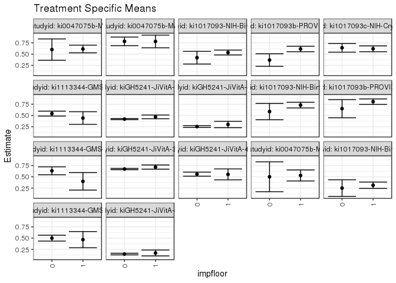

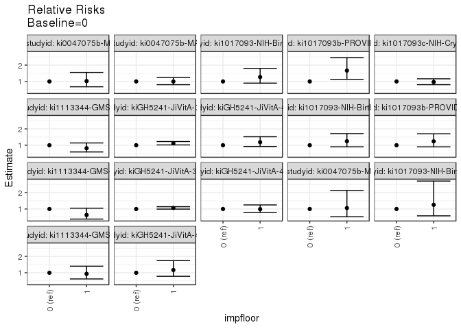

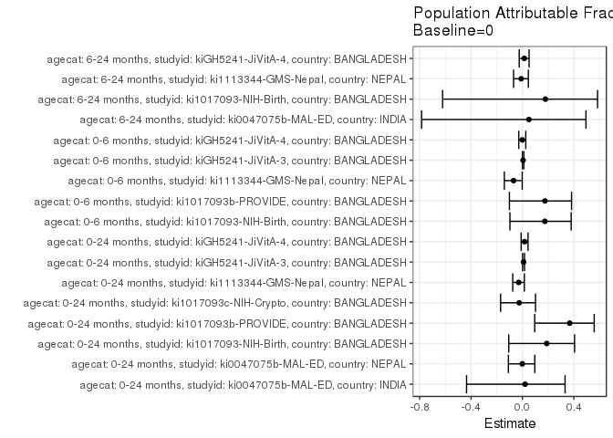

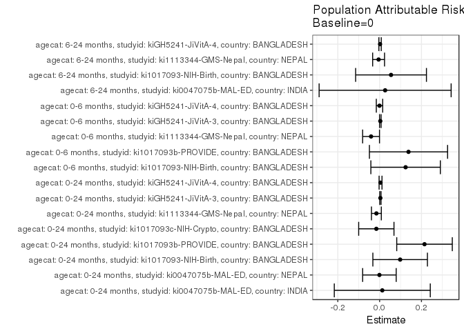

## Results Table

### Parameter: TSM

| agecat | studyid | country | intervention_level | baseline_level | estimate | ci_lower | ci_upper |
| --- | --- | --- | --- | --- | --- | --- | --- |
| 0-24 months | ki0047075b-MAL-ED | INDIA | 0 | NA | 0.6000000 | 0.3636292 | 0.8363708 |
| 0-24 months | ki0047075b-MAL-ED | INDIA | 1 | NA | 0.6139241 | 0.5287779 | 0.6990702 |
| 0-24 months | ki0047075b-MAL-ED | NEPAL | 0 | NA | 0.7826087 | 0.6870003 | 0.8782171 |
| 0-24 months | ki0047075b-MAL-ED | NEPAL | 1 | NA | 0.7804878 | 0.6404037 | 0.9205719 |
| 0-24 months | ki1017093-NIH-Birth | BANGLADESH | 0 | NA | 0.4210526 | 0.2806014 | 0.5615038 |
| 0-24 months | ki1017093-NIH-Birth | BANGLADESH | 1 | NA | 0.5346260 | 0.4802983 | 0.5889538 |
| 0-24 months | ki1017093b-PROVIDE | BANGLADESH | 0 | NA | 0.3684211 | 0.2299001 | 0.5069420 |
| 0-24 months | ki1017093b-PROVIDE | BANGLADESH | 1 | NA | 0.6133829 | 0.5527675 | 0.6739983 |
| 0-24 months | ki1017093c-NIH-Crypto | BANGLADESH | 0 | NA | 0.6395349 | 0.5427423 | 0.7363275 |
| 0-24 months | ki1017093c-NIH-Crypto | BANGLADESH | 1 | NA | 0.6177778 | 0.5528630 | 0.6826926 |
| 0-24 months | ki1113344-GMS-Nepal | NEPAL | 0 | NA | 0.5413333 | 0.4874212 | 0.5952455 |
| 0-24 months | ki1113344-GMS-Nepal | NEPAL | 1 | NA | 0.4428571 | 0.3030616 | 0.5826527 |
| 0-24 months | kiGH5241-JiVitA-3 | BANGLADESH | 0 | NA | 0.4192396 | 0.4076805 | 0.4307986 |
| 0-24 months | kiGH5241-JiVitA-3 | BANGLADESH | 1 | NA | 0.4683544 | 0.4268392 | 0.5098697 |
| 0-24 months | kiGH5241-JiVitA-4 | BANGLADESH | 0 | NA | 0.2536116 | 0.2335788 | 0.2736443 |
| 0-24 months | kiGH5241-JiVitA-4 | BANGLADESH | 1 | NA | 0.3005181 | 0.2296821 | 0.3713542 |
| 0-6 months | ki1017093-NIH-Birth | BANGLADESH | 0 | NA | 0.5862069 | 0.4057286 | 0.7666852 |
| 0-6 months | ki1017093-NIH-Birth | BANGLADESH | 1 | NA | 0.7291667 | 0.6663418 | 0.7919916 |
| 0-6 months | ki1017093b-PROVIDE | BANGLADESH | 0 | NA | 0.6500000 | 0.4495198 | 0.8504802 |
| 0-6 months | ki1017093b-PROVIDE | BANGLADESH | 1 | NA | 0.8048780 | 0.7444925 | 0.8652636 |
| 0-6 months | ki1113344-GMS-Nepal | NEPAL | 0 | NA | 0.6324786 | 0.5444051 | 0.7205521 |
| 0-6 months | ki1113344-GMS-Nepal | NEPAL | 1 | NA | 0.4000000 | 0.2059121 | 0.5940879 |
| 0-6 months | kiGH5241-JiVitA-3 | BANGLADESH | 0 | NA | 0.6725522 | 0.6586245 | 0.6864799 |
| 0-6 months | kiGH5241-JiVitA-3 | BANGLADESH | 1 | NA | 0.7154696 | 0.6689663 | 0.7619729 |
| 0-6 months | kiGH5241-JiVitA-4 | BANGLADESH | 0 | NA | 0.5590062 | 0.5146866 | 0.6033258 |
| 0-6 months | kiGH5241-JiVitA-4 | BANGLADESH | 1 | NA | 0.5538462 | 0.4328908 | 0.6748015 |
| 6-24 months | ki0047075b-MAL-ED | INDIA | 0 | NA | 0.5000000 | 0.1687592 | 0.8312408 |
| 6-24 months | ki0047075b-MAL-ED | INDIA | 1 | NA | 0.5294118 | 0.4074100 | 0.6514135 |
| 6-24 months | ki1017093-NIH-Birth | BANGLADESH | 0 | NA | 0.2500000 | 0.0656374 | 0.4343626 |
| 6-24 months | ki1017093-NIH-Birth | BANGLADESH | 1 | NA | 0.3136095 | 0.2434845 | 0.3837345 |
| 6-24 months | ki1113344-GMS-Nepal | NEPAL | 0 | NA | 0.5000000 | 0.4349044 | 0.5650956 |
| 6-24 months | ki1113344-GMS-Nepal | NEPAL | 1 | NA | 0.4666667 | 0.2867434 | 0.6465900 |
| 6-24 months | kiGH5241-JiVitA-4 | BANGLADESH | 0 | NA | 0.1471861 | 0.1289272 | 0.1654451 |
| 6-24 months | kiGH5241-JiVitA-4 | BANGLADESH | 1 | NA | 0.1718750 | 0.1065288 | 0.2372212 |

### Parameter: E(Y)

| agecat | studyid | country | intervention_level | baseline_level | estimate | ci_lower | ci_upper |
| --- | --- | --- | --- | --- | --- | --- | --- |
| 0-24 months | ki0047075b-MAL-ED | INDIA | NA | NA | 0.6127168 | 0.5323061 | 0.6931274 |
| 0-24 months | ki0047075b-MAL-ED | NEPAL | NA | NA | 0.7816092 | 0.6987929 | 0.8644255 |
| 0-24 months | ki1017093-NIH-Birth | BANGLADESH | NA | NA | 0.5191388 | 0.4683286 | 0.5699489 |
| 0-24 months | ki1017093b-PROVIDE | BANGLADESH | NA | NA | 0.5830619 | 0.5262762 | 0.6398476 |
| 0-24 months | ki1017093c-NIH-Crypto | BANGLADESH | NA | NA | 0.6237942 | 0.5698223 | 0.6777662 |
| 0-24 months | ki1113344-GMS-Nepal | NEPAL | NA | NA | 0.5258427 | 0.4754454 | 0.5762400 |
| 0-24 months | kiGH5241-JiVitA-3 | BANGLADESH | NA | NA | 0.4228375 | 0.4116972 | 0.4339777 |
| 0-24 months | kiGH5241-JiVitA-4 | BANGLADESH | NA | NA | 0.2580019 | 0.2386523 | 0.2773515 |
| 0-6 months | ki1017093-NIH-Birth | BANGLADESH | NA | NA | 0.7104072 | 0.6505603 | 0.7702542 |
| 0-6 months | ki1017093b-PROVIDE | BANGLADESH | NA | NA | 0.7880435 | 0.7295878 | 0.8464992 |
| 0-6 months | ki1113344-GMS-Nepal | NEPAL | NA | NA | 0.5915493 | 0.5100380 | 0.6730606 |
| 0-6 months | kiGH5241-JiVitA-3 | BANGLADESH | NA | NA | 0.6758416 | 0.6624927 | 0.6891906 |
| 0-6 months | kiGH5241-JiVitA-4 | BANGLADESH | NA | NA | 0.5583942 | 0.5167799 | 0.6000084 |
| 6-24 months | ki0047075b-MAL-ED | INDIA | NA | NA | 0.5263158 | 0.4116286 | 0.6410029 |
| 6-24 months | ki1017093-NIH-Birth | BANGLADESH | NA | NA | 0.3045685 | 0.2390070 | 0.3701301 |
| 6-24 months | ki1113344-GMS-Nepal | NEPAL | NA | NA | 0.4950495 | 0.4335437 | 0.5565553 |
| 6-24 months | kiGH5241-JiVitA-4 | BANGLADESH | NA | NA | 0.1492734 | 0.1316631 | 0.1668838 |

### Parameter: RR

| agecat | studyid | country | intervention_level | baseline_level | estimate | ci_lower | ci_upper |
| --- | --- | --- | --- | --- | --- | --- | --- |
| 0-24 months | ki0047075b-MAL-ED | INDIA | 0 | 0 | 1.0000000 | 1.0000000 | 1.000000 |
| 0-24 months | ki0047075b-MAL-ED | INDIA | 1 | 0 | 1.0232068 | 0.6738891 | 1.553597 |
| 0-24 months | ki0047075b-MAL-ED | NEPAL | 0 | 0 | 1.0000000 | 1.0000000 | 1.000000 |
| 0-24 months | ki0047075b-MAL-ED | NEPAL | 1 | 0 | 0.9972900 | 0.8019800 | 1.240165 |
| 0-24 months | ki1017093-NIH-Birth | BANGLADESH | 0 | 0 | 1.0000000 | 1.0000000 | 1.000000 |
| 0-24 months | ki1017093-NIH-Birth | BANGLADESH | 1 | 0 | 1.2697368 | 0.8958452 | 1.799677 |
| 0-24 months | ki1017093b-PROVIDE | BANGLADESH | 0 | 0 | 1.0000000 | 1.0000000 | 1.000000 |
| 0-24 months | ki1017093b-PROVIDE | BANGLADESH | 1 | 0 | 1.6648964 | 1.1286469 | 2.455932 |
| 0-24 months | ki1017093c-NIH-Crypto | BANGLADESH | 0 | 0 | 1.0000000 | 1.0000000 | 1.000000 |
| 0-24 months | ki1017093c-NIH-Crypto | BANGLADESH | 1 | 0 | 0.9659798 | 0.8030974 | 1.161898 |
| 0-24 months | ki1113344-GMS-Nepal | NEPAL | 0 | 0 | 1.0000000 | 1.0000000 | 1.000000 |
| 0-24 months | ki1113344-GMS-Nepal | NEPAL | 1 | 0 | 0.8180859 | 0.5877699 | 1.138650 |
| 0-24 months | kiGH5241-JiVitA-3 | BANGLADESH | 0 | 0 | 1.0000000 | 1.0000000 | 1.000000 |
| 0-24 months | kiGH5241-JiVitA-3 | BANGLADESH | 1 | 0 | 1.1171523 | 1.0181153 | 1.225823 |
| 0-24 months | kiGH5241-JiVitA-4 | BANGLADESH | 0 | 0 | 1.0000000 | 1.0000000 | 1.000000 |
| 0-24 months | kiGH5241-JiVitA-4 | BANGLADESH | 1 | 0 | 1.1849544 | 0.9241461 | 1.519367 |
| 0-6 months | ki1017093-NIH-Birth | BANGLADESH | 0 | 0 | 1.0000000 | 1.0000000 | 1.000000 |
| 0-6 months | ki1017093-NIH-Birth | BANGLADESH | 1 | 0 | 1.2438725 | 0.9035046 | 1.712464 |
| 0-6 months | ki1017093b-PROVIDE | BANGLADESH | 0 | 0 | 1.0000000 | 1.0000000 | 1.000000 |
| 0-6 months | ki1017093b-PROVIDE | BANGLADESH | 1 | 0 | 1.2382739 | 0.9014868 | 1.700882 |
| 0-6 months | ki1113344-GMS-Nepal | NEPAL | 0 | 0 | 1.0000000 | 1.0000000 | 1.000000 |
| 0-6 months | ki1113344-GMS-Nepal | NEPAL | 1 | 0 | 0.6324324 | 0.3817505 | 1.047728 |
| 0-6 months | kiGH5241-JiVitA-3 | BANGLADESH | 0 | 0 | 1.0000000 | 1.0000000 | 1.000000 |
| 0-6 months | kiGH5241-JiVitA-3 | BANGLADESH | 1 | 0 | 1.0638128 | 0.9936634 | 1.138915 |
| 0-6 months | kiGH5241-JiVitA-4 | BANGLADESH | 0 | 0 | 1.0000000 | 1.0000000 | 1.000000 |
| 0-6 months | kiGH5241-JiVitA-4 | BANGLADESH | 1 | 0 | 0.9907692 | 0.7853617 | 1.249900 |
| 6-24 months | ki0047075b-MAL-ED | INDIA | 0 | 0 | 1.0000000 | 1.0000000 | 1.000000 |
| 6-24 months | ki0047075b-MAL-ED | INDIA | 1 | 0 | 1.0588235 | 0.5250494 | 2.135242 |
| 6-24 months | ki1017093-NIH-Birth | BANGLADESH | 0 | 0 | 1.0000000 | 1.0000000 | 1.000000 |
| 6-24 months | ki1017093-NIH-Birth | BANGLADESH | 1 | 0 | 1.2544379 | 0.5807596 | 2.709580 |
| 6-24 months | ki1113344-GMS-Nepal | NEPAL | 0 | 0 | 1.0000000 | 1.0000000 | 1.000000 |
| 6-24 months | ki1113344-GMS-Nepal | NEPAL | 1 | 0 | 0.9333333 | 0.6214496 | 1.401741 |
| 6-24 months | kiGH5241-JiVitA-4 | BANGLADESH | 0 | 0 | 1.0000000 | 1.0000000 | 1.000000 |
| 6-24 months | kiGH5241-JiVitA-4 | BANGLADESH | 1 | 0 | 1.1677390 | 0.7828146 | 1.741938 |

### Parameter: PAR

| agecat | studyid | country | intervention_level | baseline_level | estimate | ci_lower | ci_upper |
| --- | --- | --- | --- | --- | --- | --- | --- |
| 0-24 months | ki0047075b-MAL-ED | INDIA | 0 | NA | 0.0127168 | -0.2167752 | 0.2422087 |
| 0-24 months | ki0047075b-MAL-ED | NEPAL | 0 | NA | -0.0009995 | -0.0812049 | 0.0792059 |
| 0-24 months | ki1017093-NIH-Birth | BANGLADESH | 0 | NA | 0.0980861 | -0.0323735 | 0.2285457 |
| 0-24 months | ki1017093b-PROVIDE | BANGLADESH | 0 | NA | 0.2146408 | 0.0818143 | 0.3474674 |
| 0-24 months | ki1017093c-NIH-Crypto | BANGLADESH | 0 | NA | -0.0157407 | -0.1001191 | 0.0686377 |
| 0-24 months | ki1113344-GMS-Nepal | NEPAL | 0 | NA | -0.0154906 | -0.0391127 | 0.0081314 |
| 0-24 months | kiGH5241-JiVitA-3 | BANGLADESH | 0 | NA | 0.0035979 | 0.0004262 | 0.0067696 |
| 0-24 months | kiGH5241-JiVitA-4 | BANGLADESH | 0 | NA | 0.0043904 | -0.0025401 | 0.0113209 |
| 0-6 months | ki1017093-NIH-Birth | BANGLADESH | 0 | NA | 0.1242003 | -0.0419492 | 0.2903499 |
| 0-6 months | ki1017093b-PROVIDE | BANGLADESH | 0 | NA | 0.1380435 | -0.0488204 | 0.3249074 |
| 0-6 months | ki1113344-GMS-Nepal | NEPAL | 0 | NA | -0.0409293 | -0.0812484 | -0.0006103 |
| 0-6 months | kiGH5241-JiVitA-3 | BANGLADESH | 0 | NA | 0.0032895 | -0.0004455 | 0.0070244 |
| 0-6 months | kiGH5241-JiVitA-4 | BANGLADESH | 0 | NA | -0.0006121 | -0.0158924 | 0.0146683 |
| 6-24 months | ki0047075b-MAL-ED | INDIA | 0 | NA | 0.0263158 | -0.2893065 | 0.3419381 |
| 6-24 months | ki1017093-NIH-Birth | BANGLADESH | 0 | NA | 0.0545685 | -0.1147328 | 0.2238699 |
| 6-24 months | ki1113344-GMS-Nepal | NEPAL | 0 | NA | -0.0049505 | -0.0333508 | 0.0234498 |
| 6-24 months | kiGH5241-JiVitA-4 | BANGLADESH | 0 | NA | 0.0020873 | -0.0036577 | 0.0078323 |

### Parameter: PAF

| agecat | studyid | country | intervention_level | baseline_level | estimate | ci_lower | ci_upper |
| --- | --- | --- | --- | --- | --- | --- | --- |
| 0-24 months | ki0047075b-MAL-ED | INDIA | 0 | NA | 0.0207547 | -0.4351619 | 0.3318375 |
| 0-24 months | ki0047075b-MAL-ED | NEPAL | 0 | NA | -0.0012788 | -0.1093840 | 0.0962920 |
| 0-24 months | ki1017093-NIH-Birth | BANGLADESH | 0 | NA | 0.1889401 | -0.1068084 | 0.4056621 |
| 0-24 months | ki1017093b-PROVIDE | BANGLADESH | 0 | NA | 0.3681270 | 0.0955195 | 0.5585715 |
| 0-24 months | ki1017093c-NIH-Crypto | BANGLADESH | 0 | NA | -0.0252338 | -0.1700308 | 0.1016439 |
| 0-24 months | ki1113344-GMS-Nepal | NEPAL | 0 | NA | -0.0294587 | -0.0757042 | 0.0147987 |
| 0-24 months | kiGH5241-JiVitA-3 | BANGLADESH | 0 | NA | 0.0085089 | 0.0009779 | 0.0159832 |
| 0-24 months | kiGH5241-JiVitA-4 | BANGLADESH | 0 | NA | 0.0170169 | -0.0101434 | 0.0434468 |
| 0-6 months | ki1017093-NIH-Birth | BANGLADESH | 0 | NA | 0.1748298 | -0.0975335 | 0.3796035 |
| 0-6 months | ki1017093b-PROVIDE | BANGLADESH | 0 | NA | 0.1751724 | -0.1014940 | 0.3823475 |
| 0-6 months | ki1113344-GMS-Nepal | NEPAL | 0 | NA | -0.0691901 | -0.1410570 | -0.0018495 |
| 0-6 months | kiGH5241-JiVitA-3 | BANGLADESH | 0 | NA | 0.0048672 | -0.0006772 | 0.0103809 |
| 0-6 months | kiGH5241-JiVitA-4 | BANGLADESH | 0 | NA | -0.0010961 | -0.0288384 | 0.0258982 |
| 6-24 months | ki0047075b-MAL-ED | INDIA | 0 | NA | 0.0500000 | -0.7852745 | 0.4944755 |
| 6-24 months | ki1017093-NIH-Birth | BANGLADESH | 0 | NA | 0.1791667 | -0.6218475 | 0.5845680 |
| 6-24 months | ki1113344-GMS-Nepal | NEPAL | 0 | NA | -0.0100000 | -0.0691757 | 0.0459005 |
| 6-24 months | kiGH5241-JiVitA-4 | BANGLADESH | 0 | NA | 0.0139831 | -0.0252188 | 0.0516859 |